# Meeting 4 - In Class Notes

Matt

2/19/2020

# Probability

- in terms of events
- probability of event A occuring - P(A)
- P(A) between 0 and 1
- If P(A) = 0, the event is impossible
- if P(A) = 1, the event is certain

## Frequentist statistics

We determine the probability of an event, but observint the frequency of that event over the long term, after many trials.

```r
head <- runif(1) > 0.5
head
```

```
## [1] FALSE
```

## Bayesian statistics

There are other perspectives in stats. Key difference between Bayes and frequentist is that Bayes lets you incorporate prior knowledge.

### Flipping a coin

- frequentist - p(heads) is approximately the frequency of getting heads after doings lot of coin flips.
- Bayes - assume p(heads) is 0.5 based on your prior experience, then do a bunch of coin flips, and update your prior based on your new knowledge.

## Properties of probability

- a random process that gives rise to an outcome
  - a coin flip is a random process
  - the outcome is heads or tails
  - a specific event might be heads
- 0 <= p(some event) <= 1
- approximate P (p-hat) $\hat{p}$, the proportion of outcomes out of the total number of trials run that match your event
  - flip a coin 100 times, get 52 heads, you would say p(heads) = 52/100

### Law of large numbers

As more observations are collected, p-hat approaches P

```r
(flip <- runif(1))
```

```
## [1] 0.1335972
```

```r
if(flip < 0.5){
  coin_flip <- "head"
} else {
  coin_flip <- "tail"
}
coin_flip
```

```
## [1] "head"
```

Let’s repeat this process 100 times

```r
# start a vector to store all of the flips in
all_flips <- c()

for(x in 1:100){
  # Flip a coin
  flip <- runif(1)

  # Identify the flip as heads or tails
  if(flip < 0.5){
    coin_flip <- "head"
  } else {
    coin_flip <- "tail"
  }

  # add this coin flip to our all_flips object
  all_flips <- c(all_flips, coin_flip)

}

all_flips == "head"
```

```
##   [1] FALSE  TRUE  TRUE  TRUE FALSE  TRUE  TRUE  TRUE  TRUE FALSE FALSE  TRUE
##  [13] FALSE  TRUE  TRUE FALSE FALSE FALSE  TRUE  TRUE FALSE  TRUE FALSE FALSE
##  [25]  TRUE  TRUE  TRUE  TRUE FALSE  TRUE  TRUE  TRUE  TRUE  TRUE FALSE  TRUE
##  [37] FALSE FALSE  TRUE FALSE FALSE FALSE  TRUE FALSE FALSE  TRUE FALSE FALSE
##  [49] FALSE  TRUE FALSE FALSE  TRUE  TRUE FALSE FALSE  TRUE FALSE FALSE  TRUE
##  [61]  TRUE FALSE  TRUE FALSE FALSE  TRUE FALSE FALSE FALSE  TRUE FALSE  TRUE
##  [73]  TRUE  TRUE FALSE  TRUE FALSE FALSE FALSE FALSE FALSE FALSE FALSE  TRUE
##  [85] FALSE  TRUE  TRUE FALSE FALSE FALSE FALSE FALSE FALSE  TRUE  TRUE FALSE
##  [97] FALSE  TRUE  TRUE  TRUE
```

```r
sum(all_flips == "head")
```

```
## [1] 47
```

```r
sum(all_flips == "head") / length(all_flips)
```

```
## [1] 0.47
```

##### Challenge: Number of coin flips it takes to get to 100 heads

Imagine you are flipping a fair coin (i.e., there is a 0.5 chance of getting a heads and a 0.5 chance of getting a tails). You want to continue flipping the coin until you get 100 heads. Write a script that simulates coin flips, and counts the number of times you need to flip the coin until you get 100 heads. Note that since the coin flip is a random process, it will not necessarily take you the same number of flips if you re-run the script.

Once you get to this, repeat it many times to determine the average number of flips required to get to 100 heads.

```r
all_flip_cnt <- c()

for(x in 1:1000){

  flip_cnt <- 0
  head_cnt <- 0

  while(head_cnt < 100){
    #flip a coin
    flip <- runif(1)
    flip_cnt <- flip_cnt + 1

    # heads/tails
    if(flip < 0.5){
      coin_flip <- "heads"
      head_cnt <- head_cnt + 1
    } else {
      coin_flip <- "tails"
    }

  }
  all_flip_cnt <- c(all_flip_cnt, flip_cnt)
}

mean(all_flip_cnt)
```

```
## [1] 199.825
```

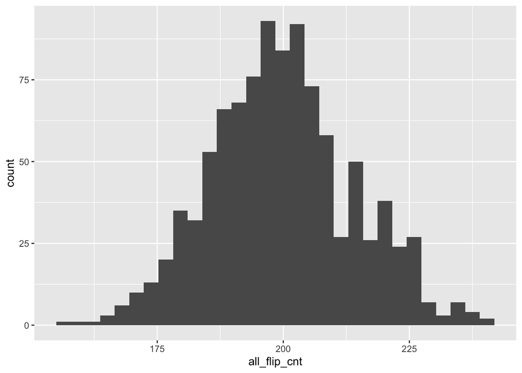

```r
library(ggplot2)

ggplot() +
  geom_histogram(aes(x = all_flip_cnt))
```